# Statistisk inferensteori Bayesiansk statistik (H & B, Kapitel 6)

## Frekventistisk och subjektiv sannolikhet

Låt \(A\) beteckna en händelse, \(P(A)\) är:

- **Frekventist**: Händelsen \(A\) är ett möjligt utfall av ett upprepbart slumpmässigt experiment, \(P(A)\) fås som empiriska andelen experiment där \(A\) inträffar.
- **Subjektiv**: \(P(A)\) är ett personligt mått på hur troligt det är att \(A\) inträffar.

## Frekventistisk och Bayesiansk statistik

Vi vill uttala oss om värdet på okänd parameter \(\theta_0\in\Theta\)

- **Frekventist**: Innan jag observerat data vet jag bara att \(\theta_0\in\Theta\).
- **Bayesian**: Innan jag observerat data kan min kunskap om värdet på \(\theta_0\) beskrivas av en sannolikhetstäthet \(p_\theta(\cdot)\), *apriorifördelningen*.

## Frekventistisk och Bayesiansk statistik

Vi vill uttala oss om värdet på okänd parameter \(\theta_0\in\Theta\) efter att ha observerat \(x\), en realisering av \(X\sim P_{\theta_0}\)

- **Frekventist**: Min skattning av \(\theta_0\) är \(\hat{\theta}(x)\), osäkerheten i min metod beskrivs av \(\hat{\theta}(X)\), \(X\sim P_\theta\).
- **Bayesian**: Min kunskap om värdet på \(\theta_0\) är nu uppdaterad till den betingade tätheten \(p_{\theta|X}(\cdot|x)\) för \(\theta|X=x\), *aposteriorifördelningen*.

## Bayes formel

Om vi tolkar \(p_{X|\theta}(x|\theta)\) som den betingade tätheten för \(X|\theta\) kan vi bestämma aposteriorifördelningen

\[ p_{\theta|X}(\cdot|x)=\frac{p_{X|\theta}(x|\cdot)p_\theta(\cdot)}{p_X(x)}\propto p_{X|\theta}(x|\cdot)p_\theta(\cdot) \]

## Exempel: Kvalitetskontroll apriorifördelning

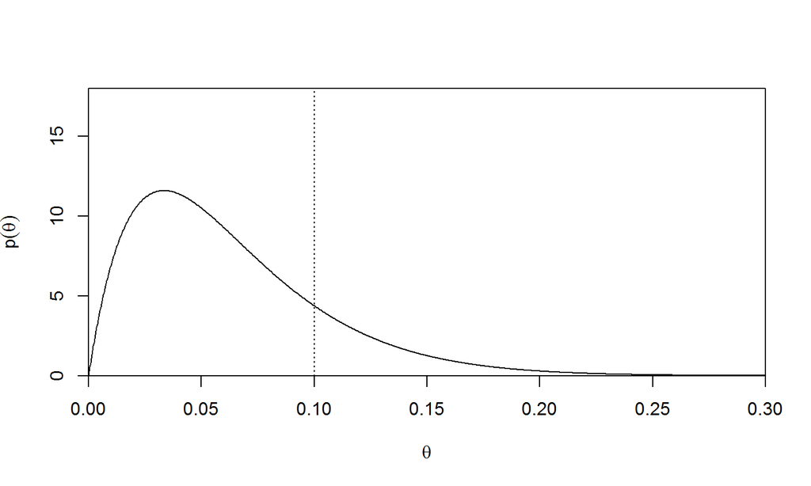

## Exempel: Kvalitetskontroll aposteriorifördelning

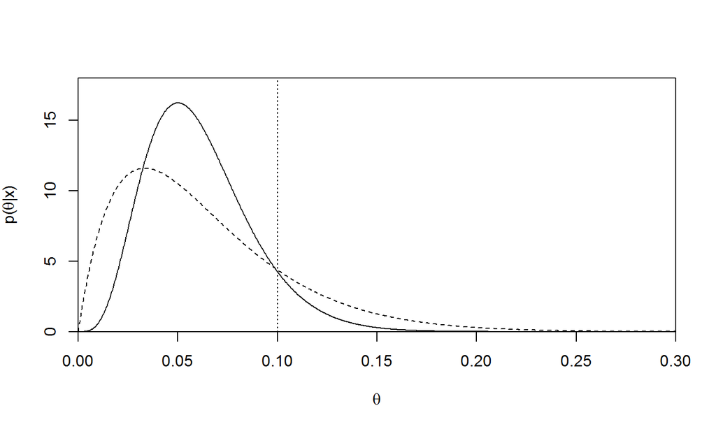

## Exempel: Kvalitetskontroll

\(P(\theta>0.1)\)

```r
1 - pbeta(0.1, 2, 30)
```

```
## [1] 0.1695646
```

\(P(\theta>0.1|X=3)\)

```r
1 - pbeta(0.1, 5, 77
          )
```

```
## [1] 0.08270474
```

## Exempel: Livslängder apriorifördelning

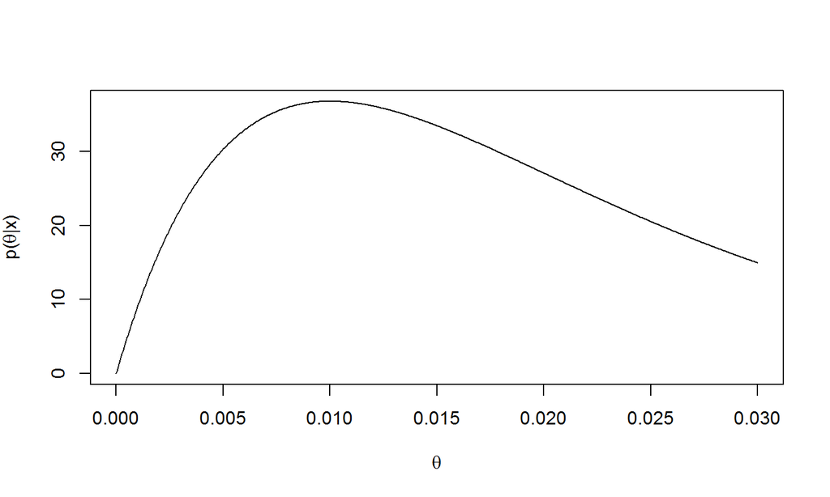

## Exempel: Livslängder aposteriorifördelning

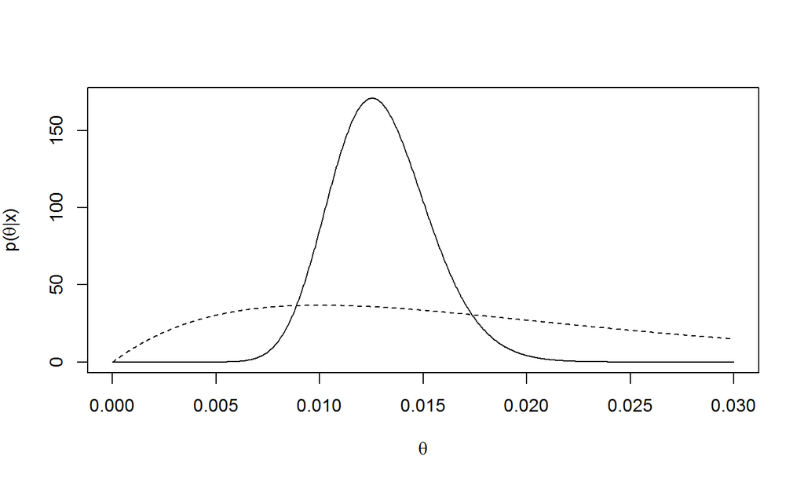

## Exempel: Livslängder, lägesmått

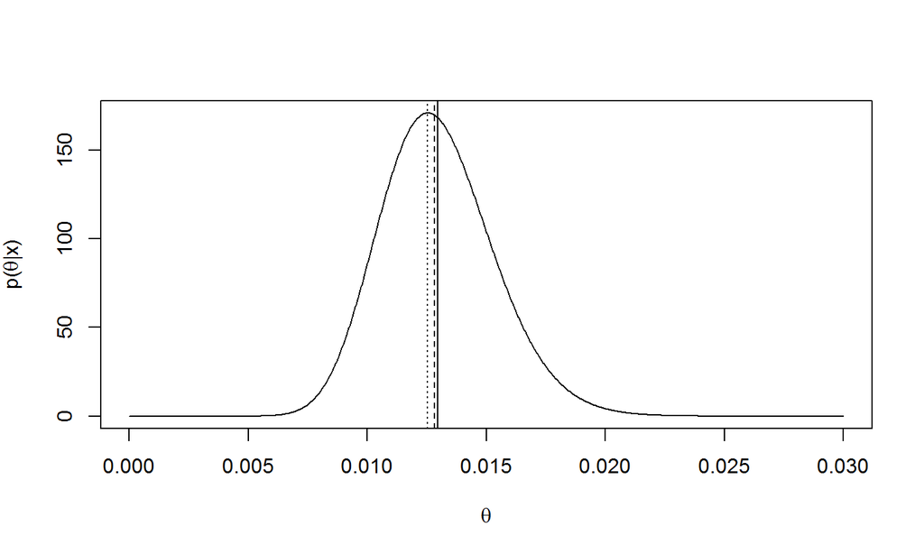

## Exempel: Livslängder, kredibilitetsintervall

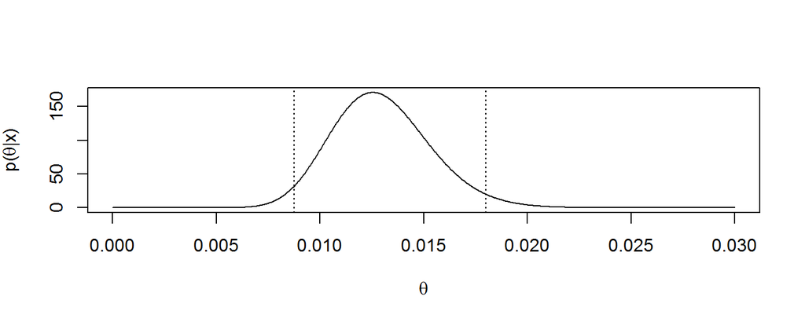

```r
qgamma(c(0.025, 0.975), 30, sum(ac) + 100)
```

```
## [1] 0.008747137 0.017998633
```

## Val av apriorifördelning

## Konjungerande familj

**Definition:** (H & B, definition 6.5) En familj fördelningar \(\mathcal{G}\) säges vara konjungerande med avseende på en likelihoodfunktion \(L(\theta)=p(x|\theta)\) om \(p(\theta|x)\in\mathcal{G}\) när \(p(\theta)\in\mathcal{G}\).

## Jeffreys prior

**Definition:** (H & B, definition 6.7) Givet en likelihood \(L(\theta)\) ges Jeffreys apriorifördelning av \[ p(\theta)\propto \sqrt{J(\theta)}. \]

## Jeffreys prior, Binomiallikelihood

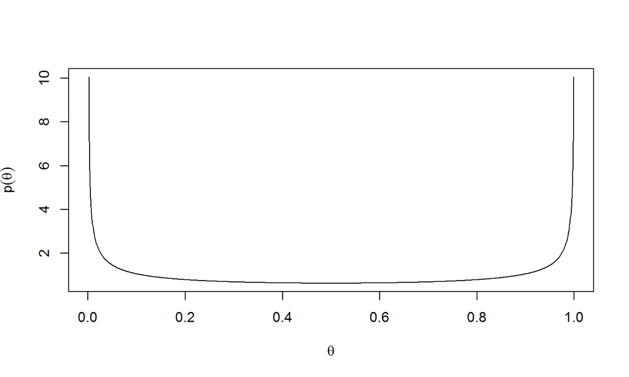

## Vektorvärda parametrar

- Frektventister pluggar in…
- Bayesianer integrerar ut:

\[ p(\theta|x)=\int p(\theta, \eta|x)\, d\eta. \]

## Trädvolymer, aposterioriförd

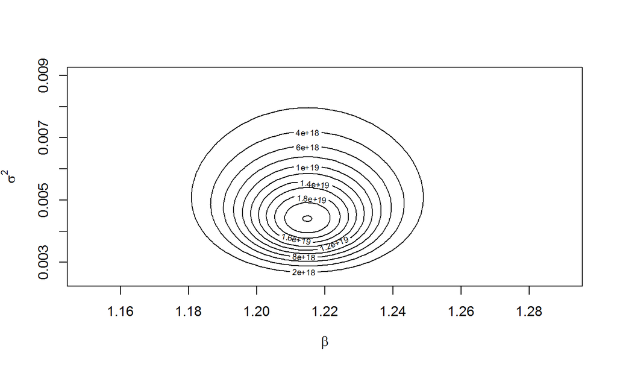

## Trädvolymer, aposterioriförd för \(\beta\)

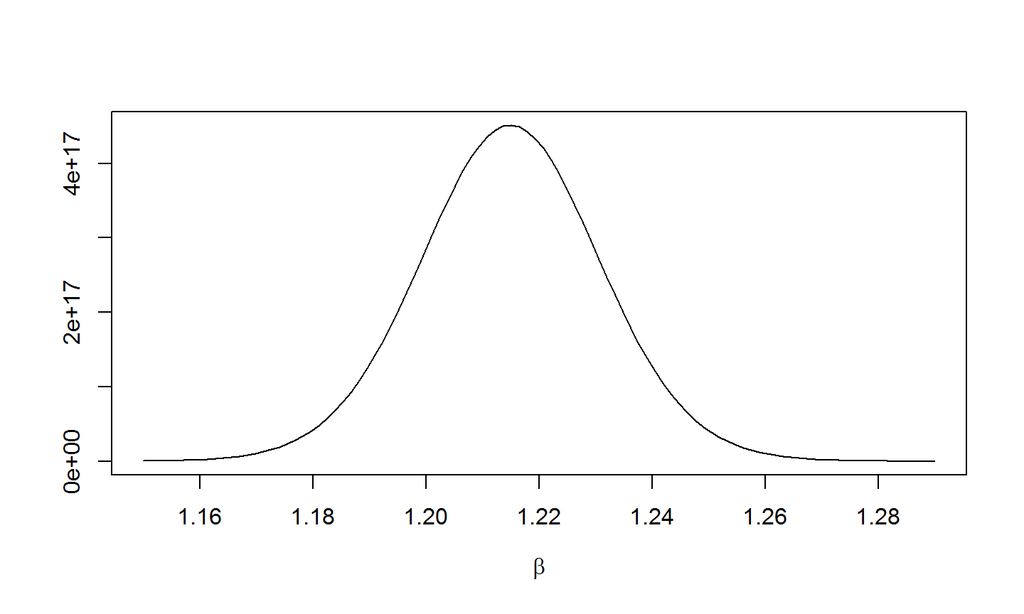

## Monte-Carlo metoder

- Svårt att integrera ut analytiskt.
- Om vi kan simulera från \(\phi=(\theta, \eta)\sim p_\phi(\cdot|x)\) kan vi även simulera från \(\theta\sim p_\theta(\cdot|x)\).
- Svårt att simulera direkt från \(p_\phi(\cdot|x)\) men lätt att simulera en Markov-process med \(p_\phi(\cdot|x)\) som stationär fördelning…

## Metropolis-Hastings (Random Walk)

Välj startvärde \(z_0\).

Upprepa för \(i=1, ..., N\):

- Låt \(z^*=z_{i-1}+\epsilon_i\), \(\epsilon_i\sim N(0,\sigma^2)\).
- Om \(f(z^*)/f(z_{i-1})> u_i\), \(u_i\sim Likf[0,1]\) låt \(z_i=z^*\), annars \(z_i=z_{-1}\)

\(z_1, ..., z_N\) är nu en dragning från en Markov-process med stationär fördelning \(f\).

## MH, Weibull

```r
post <- function(theta){L.weib(theta[1], theta[2], data = ac)}
N <- 10000 #Antal iterationer
theta <- matrix(nrow = N, ncol = 2)
theta[1,] <- c(1, 0.01) #Startvärde
sigma <- c(0.1, 0.001) #Steglängd
for (i in 2:N){
  theta.star <- theta[i-1,] + rnorm(2) * sigma
  if (post(theta.star) / post(theta[i-1,]) > runif(1))
    theta[i,] <- theta.star
  else
    theta[i,] <- theta[i-1,]
}
```

## MH, Weibull

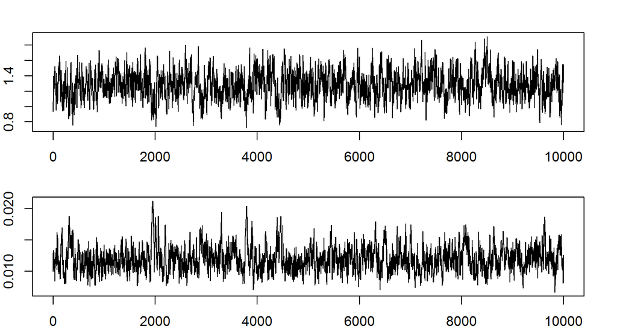

## MH, Weibull

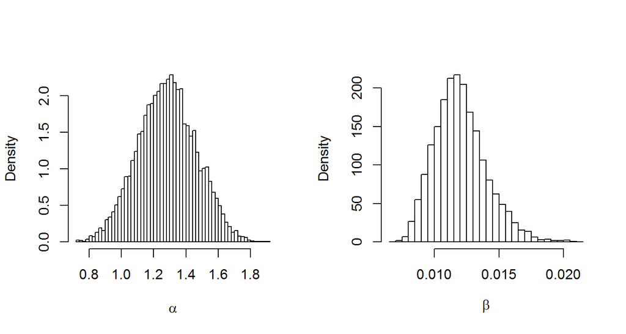

## MH, Weibull

Sannolikheten att medeltiden mellan fel är större än 100 timmar:

```r
mean(1 / theta[,2] > 100)
```

```
## [1] 0.1523
```

Sannolikheten att ett aggregat håller mer än 100 timmar:

```r
T <- rweibull(N, theta[, 1], scale = 1 / theta[, 2])
mean(T > 100)
```

```
## [1] 0.2977
```

## MH, för långa steg

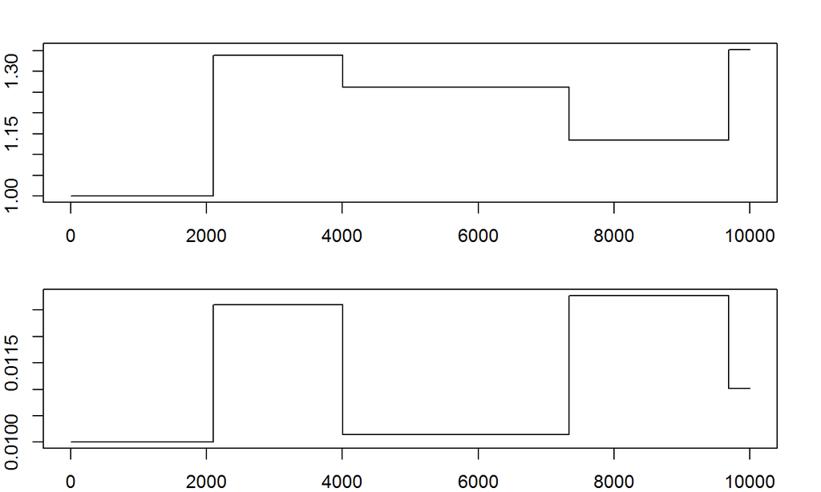

## MH, för korta steg

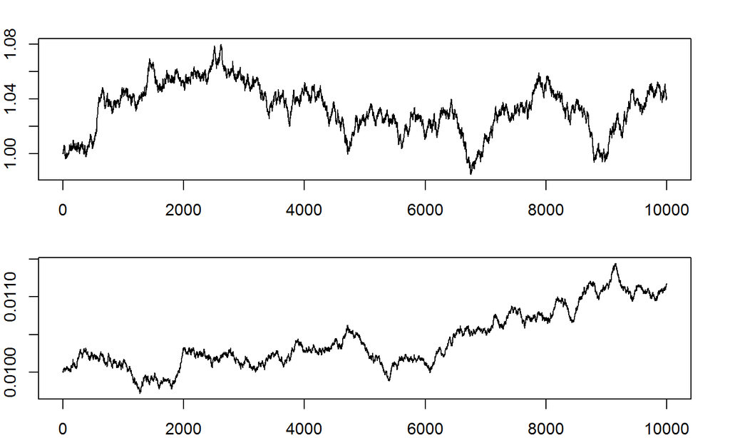

## Sammanfattning, Bayesian vs Frekventist

- Som frekventist slipper du ange apriorifördelning, men måste ofta förlita dig på asymptotiska resultat.
- Som Bayesian slipper du hänvisa till asymptotik, men måste lita på din apriorifördelning.